# first look at the dataset

- library data
- automation

## Load Library Package

“Use the [Tidyverse](https://www.tidyverse.org/), Luke” – O-W.Kenobi

```r
library(tidyverse)
library(skimr)
```

## Get Data

Crossref data used from the **Setup** to the [LC OpenRefine Workshop](https://librarycarpentry.org/lc-open-refine/setup.html)

```r
crossref_data <- read_csv("https://raw.githubusercontent.com/LibraryCarpentry/lc-open-refine/gh-pages/data/doaj-article-sample.csv",
    col_types = cols(Date = col_date(format = "%m/%d/%Y")))
```

Take a quick look at the data

```r
glimpse(crossref_data)
```

```
Observations: 1,001
Variables: 11
$ Title     <chr> "The Fisher Thermodynamics of Qu...
$ Authors   <chr> "Flavia Pennini|Angelo Plastino"...
$ DOI       <chr> "10.3390/e17127853", "10.3390/ag...
$ URL       <chr> "https://doaj.org/article/b75e8d...
$ Date      <date> 2015-01-11, 2015-01-11, 2015-01...
$ Language  <chr> "English", "English", "English",...
$ Subjects  <chr> "Fisher information|quasi-probab...
$ ISSNs     <chr> "1099-4300", "2077-0472", "1422-...
$ Publisher <chr> "MDPI AG", "MDPI AG", "MDPI AG",...
$ Citation  <chr> "Entropy, Vol 17, Iss 12, Pp 784...
$ Licence   <chr> "CC BY", "CC BY", "CC BY", "CC B...
```

```r
crossref_data
```

| Title | Authors | DOI | URL | Date | Language | Subjects | ISSNs | Publisher | Citation | Licence |
| --- | --- | --- | --- | --- | --- | --- | --- | --- | --- | --- |
| The Fisher Thermodynamics of Quasi-Probabilities | Flavia Pennini\|Angelo Plastino | 10.3390/e17127853 | https://doaj.org/article/b75e8d5cca3f46cbbd63e91be5b32412 | 2015-01-11 | English | Fisher information\|quasi-probabilities\|complementarity\|Physics\|QC1-999\|Science\|Q | 1099-4300 | MDPI AG | Entropy, Vol 17, Iss 12, Pp 7848-7858 (2015) | CC BY |
| Aflatoxin Contamination of the Milk Supply: A Pakistan Perspective | Naveed Aslam\|Peter C. Wynn | 10.3390/agriculture5041172 | https://doaj.org/article/0edc5af6672641c0bd45608812a34f9e | 2015-01-11 | English | aflatoxins\|AFM1\|AFB1\|milk marketing chains\|hepatocellular carcinoma\|Agriculture (General)\|S1-972\|Agriculture\|S | 2077-0472 | MDPI AG | Agriculture (Basel), Vol 5, Iss 4, Pp 1172-1182 (2015) | CC BY |
| Metagenomic Analysis of Upwelling-Affected Brazilian Coastal Seawater Reveals Sequence Domains of Type I PKS and Modular NRPS | Rafael R. C. Cuadrat\|Juliano C. Cury\|Alberto M. R. Dávila | 10.3390/ijms161226101 | https://doaj.org/article/d9fe469f75a0442382b84ba4f50007ee | 2015-01-11 | English | PKS\|NRPS\|metagenomics\|environmental genomics\|upwelling\|coastal environment\|Chemistry\|QD1-999\|Science\|Q | 1422-0067 | MDPI AG | International Journal of Molecular Sciences, Vol 16, Iss 12, Pp 28285-28295 (2015) | CC BY |
| Synthesis and Reactivity of a Cerium(III) Scorpionate Complex Containing a Redox Non-Innocent 2,2'-Bipyridine Ligand | Fabrizio Ortu\|Hao Zhu\|Marie-Emmanuelle Boulon\|David P. Mills | 10.3390/inorganics3040534 | https://doaj.org/article/95606ed39deb4f43b96f7e6308ad15d3 | 2015-01-11 | EN | lanthanide\|cerium\|scorpionate\|tris(pyrazolyl)borate\|radical\|redox non-innocent\|Inorganic chemistry\|QD146-197 | 2304-6740 | MDPI AG | Inorganics (Basel), Vol 3, Iss 4, Pp 534-553 (2015) | CC BY |
| Performance and Uncertainty Evaluation of Snow Models on Snowmelt Flow Simulations over a Nordic Catchment (Mistassibi, Canada) | Magali Troin\|Richard Arsenault\|François Brissette | 10.3390/hydrology2040289 | https://doaj.org/article/18b1d70730d44573ab5c264b7f93e041 | 2015-01-11 | EN | snow models\|hydrological models\|snowmelt\|uncertainty\|Canada\|Science\|Q | 2306-5338 | MDPI AG | Hydrology, Vol 2, Iss 4, Pp 289-317 (2015) | CC BY |
| Dihydrochalcone Compounds Isolated from Crabapple Leaves Showed Anticancer Effects on Human Cancer Cell Lines | Xiaoxiao Qin\|Yun Feng Xing\|Zhiqin Zhou\|Yuncong Yao | 10.3390/molecules201219754 | https://doaj.org/article/5765b418183c4b70bb0b774f4627beb5 | 2015-01-11 | English | Malus crabapples\|leaves\|dihydrochalcone compounds\|anticancer activity\|human cancer cell lines\|Organic chemistry\|QD241-441\|Chemistry\|QD1-999\|Science\|Q | 1420-3049 | MDPI AG | Molecules, Vol 20, Iss 12, Pp 21193-21203 (2015) | CC BY |
| Ionic Liquids as Carbene Catalyst Precursors in the One-Pot Four-Component Assembly of Oxo Triphenylhexanoates (OTHOs) | Anton Axelsson\|Linda Ta\|Henrik Sundén | 10.3390/catal5042052 | https://doaj.org/article/d1d39464834447c8bd9c269710e1e17d | 2015-01-11 | English | ionic liquid\|NHC\|OTHO\|multicomponent reaction\|carbene\|organocatalysis\|organogel\|MCR\|1,6-ketoester\|Physical and theoretical chemistry\|QD450-801\|Chemistry\|QD1-999\|Science\|Q | 2073-4344 | MDPI AG | Catalysts, Vol 5, Iss 4, Pp 2052-2067 (2015) | CC BY |
| Characterization of Aspartate Kinase from Corynebacterium pekinense and the Critical Site of Arg169 | Weihong Min\|Huiying Li\|Hongmei Li\|Chunlei Liu\|Jingsheng Liu | 10.3390/ijms161226098 | https://doaj.org/article/253cd7d35aa34a8eaa264da748a52e0e | 2015-01-11 | English | Corynebacterium pekinense\|aspartate kinase\|characterization\|molecular docking\|Chemistry\|QD1-999\|Science\|Q | 1422-0067 | MDPI AG | International Journal of Molecular Sciences, Vol 16, Iss 12, Pp 28270-28284 (2015) | CC BY |
| Quaternifications and Extensions of Current Algebras on S3 | Tosiaki Kori\|Yuto Imai | 10.3390/sym7042150 | https://doaj.org/article/83bb4f8f7d09467da97780b81ea0c21d | 2015-01-11 | English | infinite dimensional lie algebras\|current algebra\|lie algebra extensions\|quaternion analysis\|81R10\|17B65\|17B67\|22E67\|Physics\|QC1-999\|Science\|Q | 2073-8994 | MDPI AG | Symmetry, Vol 7, Iss 4, Pp 2150-2180 (2015) | CC BY |
| Imaging of HCC—Current State of the Art | Christina Schraml\|Sascha Kaufmann\|Hansjoerg Rempp\|Roland Syha\|Dominik Ketelsen\|Mike Notohamiprodjo\|Konstantin Nikolaou | 10.3390/diagnostics5040513 | https://doaj.org/article/39227747725f45acbe245dcf81394ee9 | 2015-01-11 | NA | hepatocellular carcinoma\|magnetic resonance imaging\|guidelines\|diffusion-weighted imaging\|dynamic contrast-enhanced magnetic resonance imaging\|computed tomography\|dual-energy computed tomography… | 2075-4418 | MDPI AG | Diagnostics, Vol 5, Iss 4, Pp 513-545 (2015) | CC BY |

[output cut: 990 more lines]

## skimr

Skimr is a easy way to have a quick look at the variables in the data frame. In this case the data are mostly character string data. With numeric data skimr will produce a thumbnail histogram (sparkline )

```r
skim(crossref_data)
```

```
Skim summary statistics
 n obs: 1001
 n variables: 11

-- Variable type:character -----------------------------------------------------
  variable missing complete    n min max empty n_unique
   Authors       0     1001 1001   7 291     0      883
  Citation       0     1001 1001  39 104     0     1000
       DOI      23      978 1001  16  29     0      977
     ISSNs       0     1001 1001   9  19     0       51
  Language      15      986 1001   2   7     0        4
   Licence       6      995 1001   5  11     0        3
 Publisher       0     1001 1001   7  47     0        6
  Subjects       0     1001 1001  17 337     0      988
     Title       0     1001 1001  18 318     0     1000
       URL       0     1001 1001  57  57     0     1000

-- Variable type:Date ----------------------------------------------------------
 variable missing complete    n        min        max     median n_unique
     Date       0     1001 1001 2015-01-01 2015-01-12 2015-01-07       12
```

## Faceting

Two methods to generate a quick table of the languages represented in the dataframe: `count()` and `forcats::fct_count`. Since these data are primarily character, it’s helpful to learn about factor data and the forcats package. These two tables are the same. It looks like the data are published in English (spelled two different ways), FRench and Spanish.

```r
crossref_data %>%
  count(Language)
```

| Language | n |
| --- | --- |
| NA | 15 |
| EN | 871 |
| English | 107 |
| ES | 7 |
| FR | 1 |

```r
fct_count(crossref_data$Language, sort = TRUE)
```

| f | n |
| --- | --- |
| EN | 871 |
| English | 107 |
| NA | 15 |
| ES | 7 |
| FR | 1 |

This time, facet on the governing license. All but six articles are covered by a [createive commons](https://creativecommons.org/) license.

```r
crossref_data %>%
  count(Licence)
```

| Licence | n |
| --- | --- |
| NA | 6 |
| CC BY | 954 |
| CC BY-NC | 11 |
| CC BY-NC-ND | 30 |

Facet on the publisher. Sort in descending order.

| Publisher | n |
| --- | --- |
| International Union of Crystallography | 858 |
| MDPI AG | 96 |
| Aurel Vlaicu University Editing House | 17 |
| Akshantala Enterprises | 13 |
| Consejo Superior de Investigaciones Científicas | 11 |
| Society of Pharmaceutical Technocrats | 6 |

Facet by authors, and sort by the most prolific. This field appears to be a multi-valued field that is pipe `|` separated. How do we count and visualize how many articles have multiple authors?

| Authors | n |
| --- | --- |
| Yoshinobu Ishikawa | 7 |
| Gihaeng Kang\|Jineun Kim\|Hyunjin Park\|Tae Ho Kim | 6 |
| M. P. Savithri\|M. Suresh\|R. Raghunathan\|R. Raja\|A. SubbiahPandi | 6 |
| Gamal A. El-Hiti\|Keith Smith\|Amany S. Hegazy\|Saud A. Alanazi\|Benson M. Kariuki | 5 |
| Gihaeng Kang\|Jineun Kim\|Eunjin Kwon\|Tae Ho Kim | 5 |
| Hea-Chung Joo\|Ki-Min Park\|Uk Lee | 5 |
| Dohyun Moon\|Jong-Ha Choi | 4 |
| M. S. Krishnamurthy\|Noor Shahina Begum | 4 |
| Rajamani Raja\|Subramani Kandhasamy\|Paramasivam T. Perumal\|A. SubbiahPandi | 4 |
| Augusto Rivera\|Jicli José Rojas\|Jaime Ríos-Motta\|Michael Bolte | 3 |

[output cut: 873 more lines]

The above table is not very useful (unless tracking publishing teams that are always expressed identically.) Let’s exploring some methods to generate a count of the pipe character separating each author in a single author field. The `stringr::str_count()` function is a great way to calculate the number of delimiters in each author field.

Note that counting a pipe character `|` requires using a Regular Expression, or [regex](https://en.wikipedia.org/wiki/Regular_expression). Anyone manipulating string characters with computers will be far more capable after spending some time learning about regular expressions. In this case the we’re looking for a pipe character `|`. The special trick, here, in understanding regex is to know that a pipe character has special meaning. Therefore we have to escape, or make it know that we want the literal pipe character and not the special meaning pipe character. To escape a character in regex one uses a backslash `\`. But the weird part is that, in R, one has to escape the the escape character: `\\|` means look for a literal `|`.

Below we count the number of pipe characters in each row of the Author field. Using the `head` function we only display the first six values (rows) in the Author column.

```r
str_count(crossref_data$Authors, "\\|") %>% head()
```

```
[1] 1 1 2 3 2 3
```

## Transform Data

Use `dplyr::mutate` to generate a new field that calculates how many authors each observation contains.

```r
crossref_data %>%
  select(Authors) %>%
  mutate(multi_authorship = str_count(Authors, "\\|") + 1) %>%
  select(Authors, multi_authorship)
```

| Authors | multi_authorship |
| --- | --- |
| Flavia Pennini\|Angelo Plastino | 2 |
| Naveed Aslam\|Peter C. Wynn | 2 |
| Rafael R. C. Cuadrat\|Juliano C. Cury\|Alberto M. R. Dávila | 3 |
| Fabrizio Ortu\|Hao Zhu\|Marie-Emmanuelle Boulon\|David P. Mills | 4 |
| Magali Troin\|Richard Arsenault\|François Brissette | 3 |
| Xiaoxiao Qin\|Yun Feng Xing\|Zhiqin Zhou\|Yuncong Yao | 4 |
| Anton Axelsson\|Linda Ta\|Henrik Sundén | 3 |
| Weihong Min\|Huiying Li\|Hongmei Li\|Chunlei Liu\|Jingsheng Liu | 5 |
| Tosiaki Kori\|Yuto Imai | 2 |
| Christina Schraml\|Sascha Kaufmann\|Hansjoerg Rempp\|Roland Syha\|Dominik Ketelsen\|Mike Notohamiprodjo\|Konstantin Nikolaou | 7 |

[output cut: 990 more lines]

## Visualize

### Authors

Generate a histogram distribution of the multiple authorship variable.

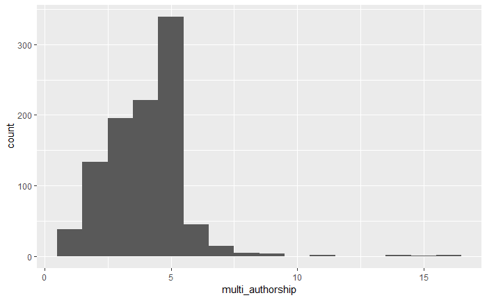

```r
crossref_data %>%
  select(Authors) %>%
  mutate(multi_authorship = str_count(Authors, "\\|") + 1) %>%
  select(multi_authorship, Authors) %>%
  ggplot() +
  aes(multi_authorship) +
  geom_histogram(binwidth = 1)
```

This time generate as a bar graph and sort by the most frequent representation. Articles with five authors is the most frequent representation in the dataset.

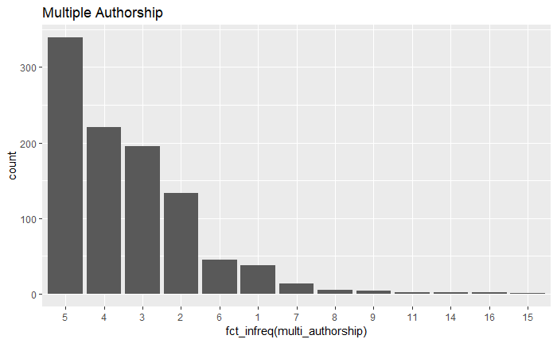

```r
auth_count <- crossref_data %>%
  select(Authors) %>%
  mutate(multi_authorship = str_count(Authors, "\\|") + 1) %>%
  mutate(multi_authorship = as.character(multi_authorship)) %>%
  select(multi_authorship, Authors)

ggplot(auth_count) +
  aes(fct_infreq(multi_authorship)) +
  geom_bar() +
  #coord_flip() +
  ggtitle("Multiple Authorship")
```

### Explore Subject Headings

Visualize the frequency of multiple subject headings, just as with authors (A bar graph and a histogram)

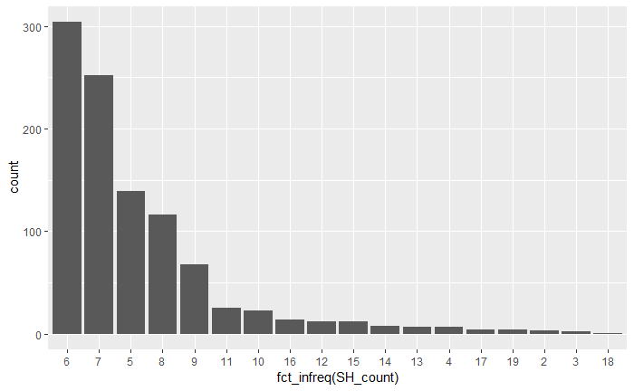

```r
crossref_data %>%
  mutate(SH_count = str_count(Subjects, "\\|") + 1) %>%
  mutate(SH_count = as.character(SH_count)) %>%
  ggplot() +
  aes(fct_infreq(SH_count)) +
  geom_bar()
```

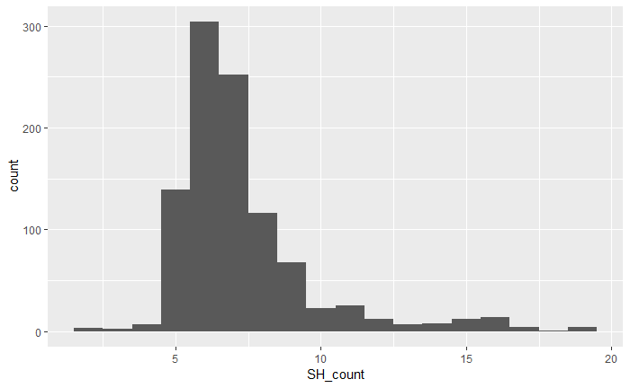

```r
crossref_data %>%
  mutate(SH_count = str_count(Subjects, "\\|") + 1) %>%
  ggplot() +
  aes(SH_count) +
  geom_histogram(binwidth = 1)
```

## Data Transformations

`dplyr::case_when()` is one specialized way to perform an `if_else` transformation.

```r
crossref_data %>%
  count(Language)
```

| Language | n |
| --- | --- |
| NA | 15 |
| EN | 871 |
| English | 107 |
| ES | 7 |
| FR | 1 |

```r
crossref_data <- crossref_data %>%
  mutate(Language = case_when(
    Language == "EN" ~ "English",
    Language == "ES" ~ "Spanish",
    Language == "FR" ~ "French"
  ))
```

### Visualize the Languages.

Stacked Bar graph shows frequency by Language. Each stack of a bar distinguishes the publishers. English Language is huge and somewhat over-powers the reset of the graph. Make a second graph (below) to drill down on the lesser represented languages.

[figure not shown]

```r
crossref_data %>%
  ggplot() +
  aes(fct_infreq(Language), fill = Publisher) +
  geom_bar()
```

Filter the data to show only the “NA”, “French”, and “Spanish”.

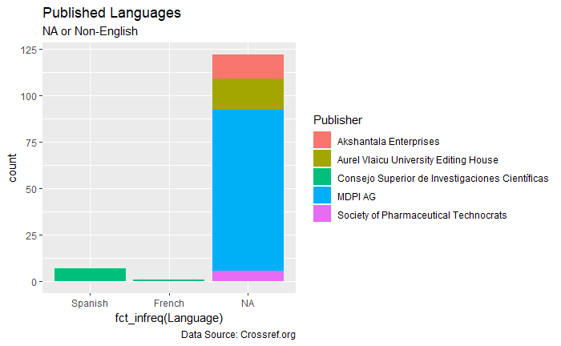

```r
crossref_data %>%
  filter(is.na(Language) | Language == "French" | Language == "Spanish") %>%
  ggplot() +
  aes(fct_infreq(Language), fill = Publisher) +
  geom_bar() +
  labs(title = "Published Languages",
       subtitle = "NA or Non-English",
       caption = "Data Source: Crossref.org")
```

## Time Series

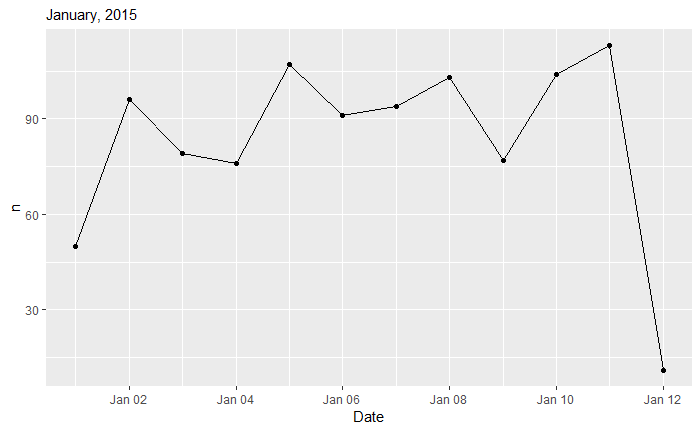

```r
crossref_data %>%
  count(Date) %>%
  ggplot(aes(Date, n)) +
  geom_point() +
  geom_line() +
  labs("Publishing Frequency by Day",
       subtitle = "January, 2015")
```

```r
NA
```